# EnsembleMethods

Ranjit Mishra

June 28, 2019

## Random Forests & Bagging

Used for trees as building blocks to build more complex models. Random forests build lots of bushy trees, and then average them to reduce the variance. Bagging uses all variables and is same as random forest in terms of mathemetics. Here we will use the Bosotn data to explore random forests and boosting. Lets start with a simple tree and compare its result with forest based trees

```r
boston <- read.csv("~/Analytics/Boston.csv", sep = ",", header = TRUE)
str(boston)
```

```
## 'data.frame':    506 obs. of  14 variables:
##  $ crim   : num  0.00632 0.02731 0.02729 0.03237 0.06905 ...
##  $ zn     : num  18 0 0 0 0 0 12.5 12.5 12.5 12.5 ...
##  $ indus  : num  2.31 7.07 7.07 2.18 2.18 2.18 7.87 7.87 7.87 7.87 ...
##  $ chas   : int  0 0 0 0 0 0 0 0 0 0 ...
##  $ nox    : num  0.538 0.469 0.469 0.458 0.458 0.458 0.524 0.524 0.524 0.524 ...
##  $ rm     : num  6.58 6.42 7.18 7 7.15 ...
##  $ age    : num  65.2 78.9 61.1 45.8 54.2 58.7 66.6 96.1 100 85.9 ...
##  $ dis    : num  4.09 4.97 4.97 6.06 6.06 ...
##  $ rad    : int  1 2 2 3 3 3 5 5 5 5 ...
##  $ tax    : int  296 242 242 222 222 222 311 311 311 311 ...
##  $ ptratio: num  15.3 17.8 17.8 18.7 18.7 18.7 15.2 15.2 15.2 15.2 ...
##  $ black  : num  397 397 393 395 397 ...
##  $ lstat  : num  4.98 9.14 4.03 2.94 5.33 ...
##  $ medv   : num  24 21.6 34.7 33.4 36.2 28.7 22.9 27.1 16.5 18.9 ...
```

```r
summary(boston)
```

```
##       crim                zn             indus            chas
##  Min.   : 0.00632   Min.   :  0.00   Min.   : 0.46   Min.   :0.00000
##  1st Qu.: 0.08204   1st Qu.:  0.00   1st Qu.: 5.19   1st Qu.:0.00000
##  Median : 0.25651   Median :  0.00   Median : 9.69   Median :0.00000
##  Mean   : 3.61352   Mean   : 11.36   Mean   :11.14   Mean   :0.06917
##  3rd Qu.: 3.67708   3rd Qu.: 12.50   3rd Qu.:18.10   3rd Qu.:0.00000
##  Max.   :88.97620   Max.   :100.00   Max.   :27.74   Max.   :1.00000
##       nox               rm             age              dis
##  Min.   :0.3850   Min.   :3.561   Min.   :  2.90   Min.   : 1.130
##  1st Qu.:0.4490   1st Qu.:5.886   1st Qu.: 45.02   1st Qu.: 2.100
##  Median :0.5380   Median :6.208   Median : 77.50   Median : 3.207
##  Mean   :0.5547   Mean   :6.285   Mean   : 68.57   Mean   : 3.795
##  3rd Qu.:0.6240   3rd Qu.:6.623   3rd Qu.: 94.08   3rd Qu.: 5.188
##  Max.   :0.8710   Max.   :8.780   Max.   :100.00   Max.   :12.127
##       rad              tax           ptratio          black
##  Min.   : 1.000   Min.   :187.0   Min.   :12.60   Min.   :  0.32
##  1st Qu.: 4.000   1st Qu.:279.0   1st Qu.:17.40   1st Qu.:375.38
##  Median : 5.000   Median :330.0   Median :19.05   Median :391.44
##  Mean   : 9.549   Mean   :408.2   Mean   :18.46   Mean   :356.67
##  3rd Qu.:24.000   3rd Qu.:666.0   3rd Qu.:20.20   3rd Qu.:396.23
##  Max.   :24.000   Max.   :711.0   Max.   :22.00   Max.   :396.90
##      lstat            medv
##  Min.   : 1.73   Min.   : 5.00
##  1st Qu.: 6.95   1st Qu.:17.02
##  Median :11.36   Median :21.20
##  Mean   :12.65   Mean   :22.53
##  3rd Qu.:16.95   3rd Qu.:25.00
##  Max.   :37.97   Max.   :50.00
```

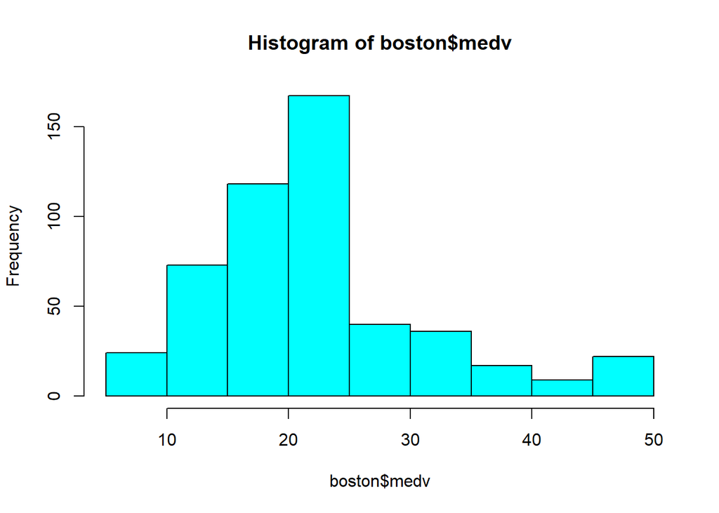

```r
hist(boston$medv, col = 'cyan')
```

## Regression Tree

Here we fit a regression tree to the Boston data set. First, we create a training set, and fit the tree to the training data

```r
set.seed (21)
library(tree)

train = sample (1: nrow(boston), nrow(boston)/2)

tree.boston = tree(medv ~., boston ,subset =train)

tree.boston
```

```
## node), split, n, deviance, yval
##       * denotes terminal node
##
##  1) root 253 23340.00 22.86
##    2) lstat < 9.755 108  9223.00 30.46
##      4) rm < 6.941 70  2902.00 25.98
##        8) nox < 0.602 65  1086.00 24.86
##         16) rm < 6.543 34   294.10 22.09 *
##         17) rm > 6.543 31   246.40 27.89 *
##        9) nox > 0.602 5   680.00 40.50 *
##      5) rm > 6.941 38  2320.00 38.72
##       10) rm < 7.4525 21   567.30 34.39 *
##       11) rm > 7.4525 17   870.00 44.08
##         22) ptratio < 16.15 10    85.30 47.53 *
##         23) ptratio > 16.15 7   495.00 39.14 *
##    3) lstat > 9.755 145  3238.00 17.20
##      6) lstat < 15.99 74   661.20 20.21 *
##      7) lstat > 15.99 71  1213.00 14.07
##       14) crim < 16.5774 61   745.00 15.03 *
##       15) crim > 16.5774 10    70.24  8.23 *
```

## Summary of the tree

Notice that the output of summary() indicates that only five of the variables have been used in constructing the tree. In the context of a regression tree, the deviance is simply the sum of squared errors for the tree

```r
summary(tree.boston)
```

```
##
## Regression tree:
## tree(formula = medv ~ ., data = boston, subset = train)
## Variables actually used in tree construction:
## [1] "lstat"   "rm"      "nox"     "ptratio" "crim"
## Number of terminal nodes:  9
## Residual mean deviance:  15.76 = 3845 / 244
## Distribution of residuals:
##     Min.  1st Qu.   Median     Mean  3rd Qu.     Max.
## -17.2400  -1.7310   0.1088   0.0000   1.9910  15.6100
```

## Plot the tree

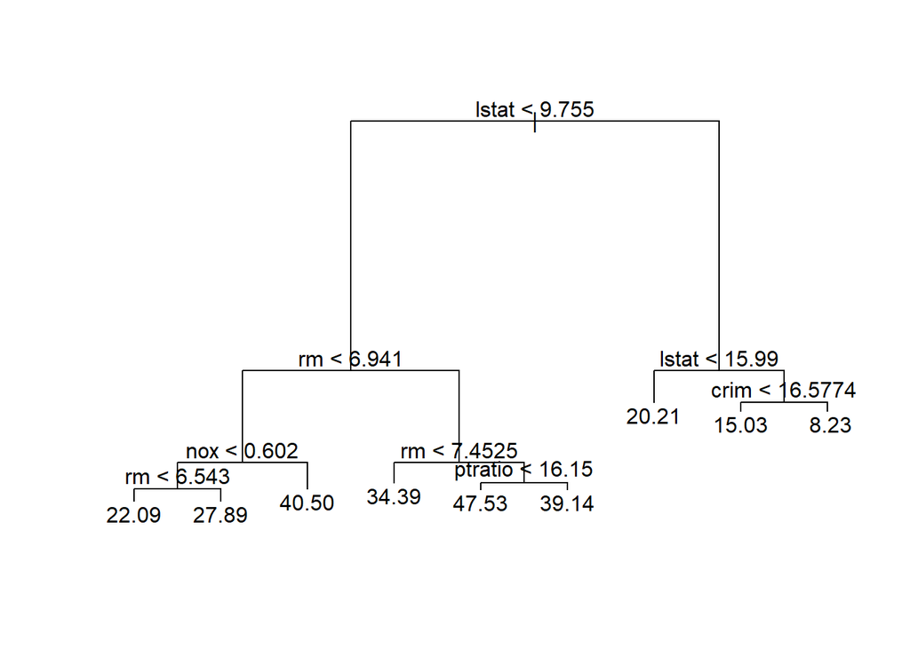

```r
plot(tree.boston)
text(tree.boston, pretty= 0)
```

## Use the Tree for Prediction

We are not using pruning of the tree for this demonstration. Lets use the unpruned tree to make predictions on the test set.

```r
set.seed(21)
yhat <- predict(tree.boston, newdata = boston[-train ,])

yhat.test <- boston[-train, "medv"]
mse = mean((yhat - yhat.test)**2)
cat('MSE from regression tree is: ',mse )
```

```
## MSE from regression tree is:  18.77192
```

## Bagging

```r
library(randomForest)
set.seed(21)

bag.boston = randomForest(medv ~ ., data=boston,         subset=train, mtry= 8, importance =TRUE)

bag.boston
```

```
##
## Call:
##  randomForest(formula = medv ~ ., data = boston, mtry = 8, importance = TRUE,      subset = train)
##                Type of random forest: regression
##                      Number of trees: 500
## No. of variables tried at each split: 8
##
##           Mean of squared residuals: 14.92271
##                     % Var explained: 83.82
```

```r
yhat.bag = predict (bag.boston, newdata = boston[-train ,])

cat('MSE from bagging is: ', (mean(( yhat.bag - yhat.test)^2)))
```

```
## MSE from bagging is:  9.659542
```

## Bagging - Plots

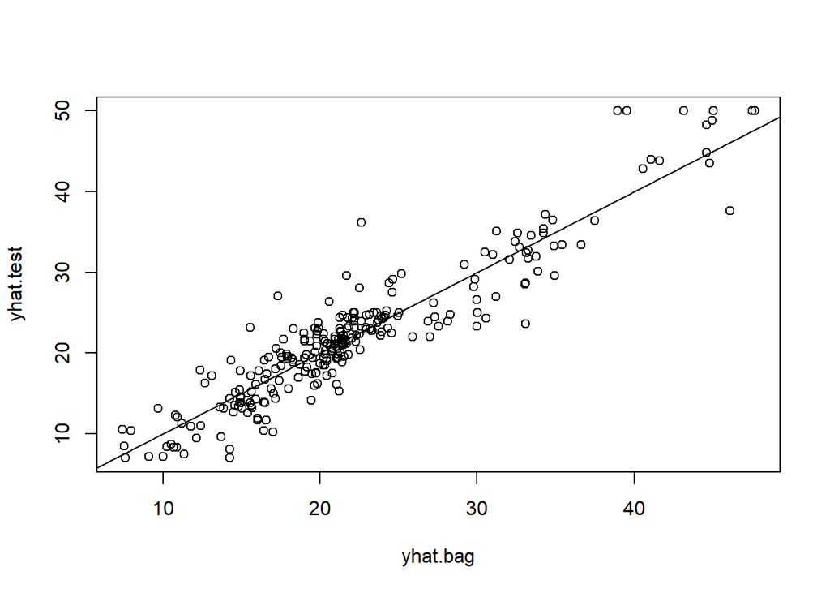

```r
plot(yhat.bag , yhat.test)
abline (0,1)
```

## Bagging ImpVar

Two measures of variable importance are reported. The former is based upon the mean decrease of accuracy in predictions on the out of bag samples when a given variable is excluded from the model. The latter is a measure of the total decrease in node impurity that results from splits over that variable, averaged over all trees. In the case of regression trees, the node impurity is measured by the training RSS, and for classification trees by the deviance. Plots of these importance measures can also be produced

```r
importance (bag.boston)
```

```
##             %IncMSE IncNodePurity
## crim    11.65125034     946.45340
## zn      -0.06780456      25.75168
## indus    7.78963092     503.30440
## chas     2.84657873     116.38669
## nox     14.00605957    1165.93705
## rm      36.23033195    7006.89056
## age     11.26705950     778.70485
## dis     14.93791032    1360.57549
## rad      6.41875306     157.71362
## tax      7.27973016     230.77936
## ptratio 13.23539720     902.58208
## black    3.53916815     261.42430
## lstat   32.06288283    9405.05521
```

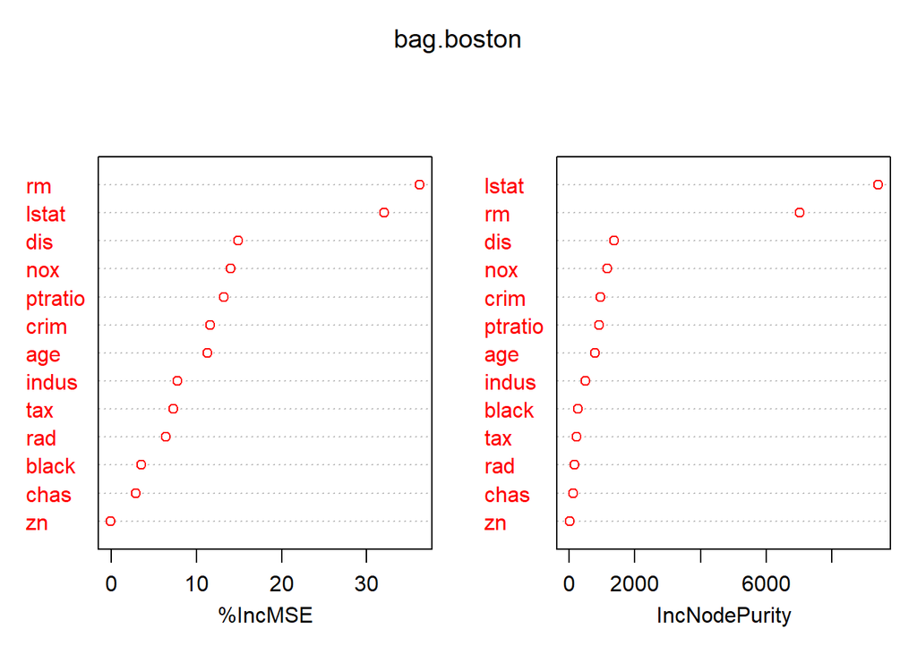

```r
varImpPlot (bag.boston, col = 'red' )
```